# Reproducible Research: A Brief Analysis of severe weather events in USA

Sam Mallisetti

August 3, 2018

## Data Processing

The raw dataset came in a bzip2 compressed format. Data processing steps are described below. 1. The data for this assignment come in the form of a comma-separated-value file compressed via the bzip2 algorithm to reduce its size. You can download the file from the course web site:Storm Data [47Mb] (https://d396qusza40orc.cloudfront.net/repdata%2Fdata%2FStormData.csv.bz2). Then unzip the file into CSV format. This dataset contains around 1 million rows (902,297) and 37 columns. Load into data frame sdata_raw.

```r
library(R.utils)
bunzip2("StormData.csv.bz2", "StormData.csv", remove = FALSE, skip = TRUE)
```

```
## [1] "StormData.csv"
## attr(,"temporary")
## [1] FALSE
```

```r
sdata_raw <- read.csv("StormData.csv")
```

2. Filter out the columns not needed for further analysis. We are interested only in aggregate analysis. We can eliminate date dimension and most non-quantitative variables. We need only 5 columns: Event type, Fatalities, Injuries, Property damage, and Crop damage. sdata1 contains around 1 million rows and 5 columns.

```r
sdata1 <- subset(sdata_raw, select = c("EVTYPE","FATALITIES","INJURIES","PROPDMG","CROPDMG"))
```

3. Many event types are duplicated using a variety of descriptions, e.g. “blowing snow” & “BLOWING SNOW”. Consolidate event types by eliminating most of the duplicates.

```r
tornado_ct <- grep("TORNADO", sdata1$EVTYPE)
sdata1[tornado_ct,1] <- "TORNADO"
wind_ct <- grep("WIND", sdata1$EVTYPE)
sdata1[wind_ct,1] <- "WIND"
flood_ct <- grep("FLOOD", sdata1$EVTYPE)
sdata1[flood_ct,1] <- "FLOOD"
snow_ct <- grep("SNOW", sdata1$EVTYPE)
sdata1[snow_ct,1] <- "SNOW"
heat_ct <- grep("HEAT", sdata1$EVTYPE)
sdata1[heat_ct,1] <- "HEAT"
storm_ct <- grep("STORM", sdata1$EVTYPE)
sdata1[storm_ct,1] <- "STORM"
```

4. Perform aggregation by event type of all the other four metrics. There are 985 event types. We are interested in finding out which event types cause most harm. So, we can aggregate by event type and reduce this large dataset to a summary dataset of 537 rows. This is contained in sdata_s dataframe.

```r
library("dplyr")
sdata_grp <- group_by(sdata1, EVTYPE)
sdata_s <- summarize(sdata_grp, fat_sum=sum(FATALITIES), inj_sum=sum(INJURIES), prop_sum=sum(PROPDMG), crop_sum=sum(CROPDMG))
```

5. Some more data cleansing is needed. When exploring the summary dataframe I noticed that majority of the events have zero counts. We can drop these rows. This reduces the resulting dataframe sdata_s1 to 230 rows.

```r
sdata_s1 <- subset(sdata_s, fat_sum > 0 | inj_sum > 0 | prop_sum > 0 | crop_sum > 0)
```

## Results

1. To analyze Fatalities, using only the Event type and Fatalities columns in a separate data frame, sort in descending order of Fatalities. Use the Top 10 to make a plot and determine the most harmful event type. Tornado event type caused the most number of fatalities (5,611); followed by Heat (3,138), Flood (1,549), Wind (1,438) and Lightning (816).

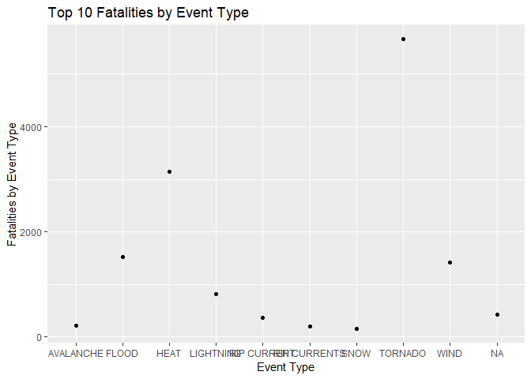

```r
library("ggplot2")
sdata_sf <- sdata_s1[,c(1,2)]
sdata_sf <- arrange(sdata_sf, desc(fat_sum))
sdata_f10 <- head(sdata_sf, 10)
ggplot(data=sdata_f10, aes(x=EVTYPE, y=fat_sum)) + geom_point() + ggtitle("Top 10 Fatalities by Event Type") + xlab("Event Type") + ylab("Fatalities by Event Type")
```

2. To analyze Injuries, using only the Event type and Injuries columns in a separate data frame, sort in descending order of Injuries. Use the Top 10 to make a plot and determine the most harmful event type. Tornado event type caused the most number of injuries (90,969); followed by Wind (11,552), Heat (9,157), Flood (8,820) and Lightning (5,230).

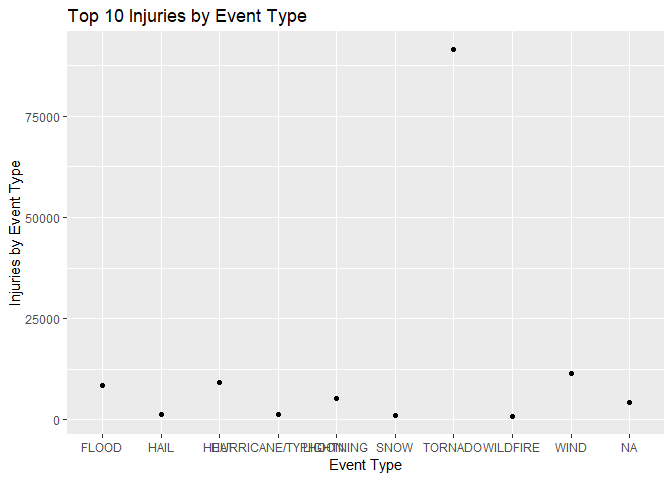

```r
sdata_si <- sdata_s1[,c(1,3)]
sdata_si <- arrange(sdata_si, desc(inj_sum))
sdata_i10 <- head(sdata_si, 10)
ggplot(data=sdata_i10, aes(x=EVTYPE, y=inj_sum)) + geom_point() + ggtitle("Top 10 Injuries by Event Type") + xlab("Event Type") + ylab("Injuries by Event Type")
```

3. To analyze asset damage, using only the Event type, Property damage and Crop damage columns in a separate data frame. Create a new variable that is the sum of Property damage and Crop damage in dollar value. Sort in descending order of asset damage. Use the Top 10 to make a plot and determine the most harmful event type. Wind event type caused the most amount of asset damage (property + crop) ($3,361K); followed by Tornado (3,308K), Flood (2,798K), Hail (1,268K) and Lightning (607K).

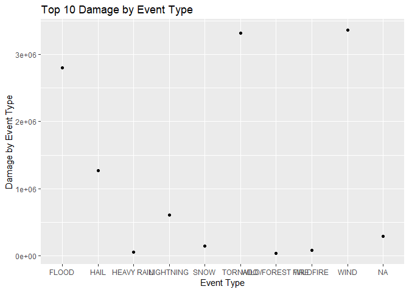

```r
sdata_s1$asset_sum <- sdata_s1$prop_sum + sdata_s1$crop_sum
sdata_sd <- sdata_s1[,c(1,6)]
sdata_sd <- arrange(sdata_sd, desc(asset_sum))
sdata_d10 <- head(sdata_sd, 10)
ggplot(data=sdata_d10, aes(x=EVTYPE, y=asset_sum)) + geom_point() + ggtitle("Top 10 Damage by Event Type") + xlab("Event Type") + ylab("Damage by Event Type")
```

#